# act_report

## Report: act_report for WeRateDogs Archive

From the wrangling and EDA done on the dataset, we were able to deduce the following;

1. There are more tweets in year 2016 (1019) compared to other years, and of these there are 819 unique retweets, i.e they're retweeted by 819 different users, as well as 904 unique likes, that is 904 different user like the tweets. We noticed that the number of tweets reduced as we moved into 2017. The unique ratings for the year 2015, 2016, and 2017 are 17, 27, and 10 respectively. We can easily see that there are more different ratings in 2016 compared to other years, perhaps due to more tweets than any other years. Score 11 is the top rating dogs had in 2016, whereas 13 was the topmost score for dogs in the year 2017, even though least tweets were twitted that year.

Below is the plot of Tweet Count By Year

#### Tweet Count By Year

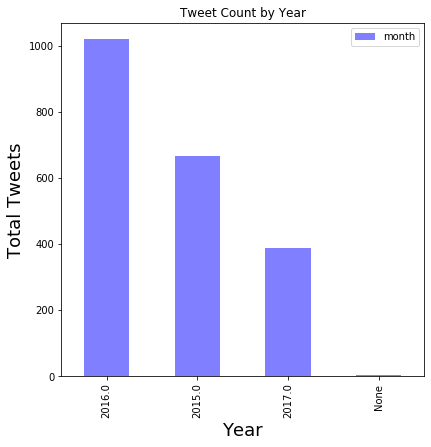

1. There are more tweets in the month of December (428) compared to other months, and of these, there are 380 unique retweets, i.e they're retweeted by 380 different users, as well as liked by 400 different users. We can easily see that December also has the more unique ratings (18) than any other months, also due to more tweet in that month. Score 10 appears to be the preferred score rating for those that tweets this month.

Below is the plot of Tweet Count By Month

#### Tweet Count By Months

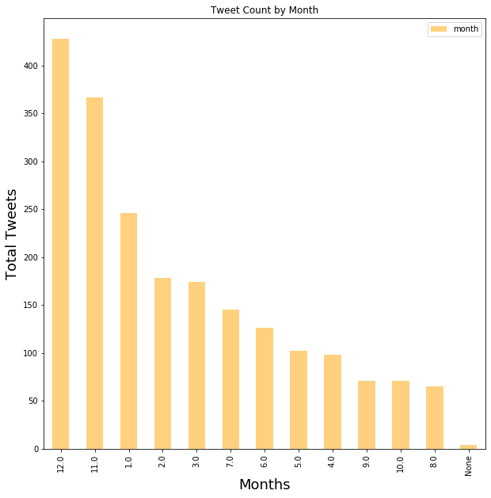

1. There are more tweets on Mondays (339) compared to other days, and of these, there are 314 unique retweets, i.e they're retweeted by 314 different users, as well as liked by 320 different users. Which is supprising compared to the second day most people do tweets Wednesday having a total of 313 tweets. Saturday has more unique rating 21, compared to Monday 17, which happens to be the day with highest tweets.

#### Tweet Count By Day

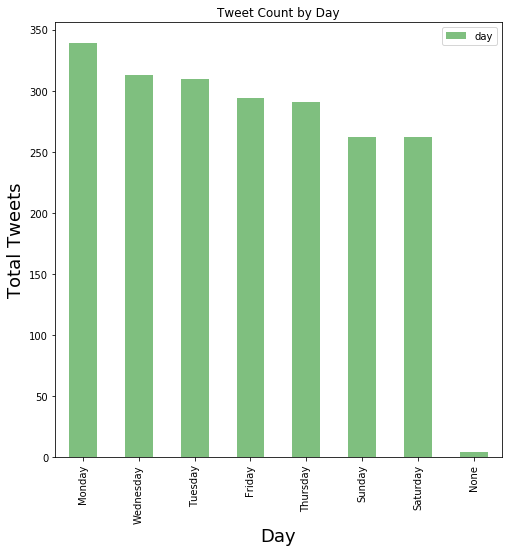